# Vorbereitung

## Studien

Konfigurationen die mit dem *IRTlib-Editor* erstellt werden, werden in sogenannten *Studien* zusammengefasst. Eine *Studie* soll die Assessmentinhalte zusammenfassen, welche in einer Erhebung oder Sitzung administriert werden.

### Studienverwaltung

Nach dem Start des *IRTlib-Editors* wird die Ansicht *Studien* angezeigt. In dieser Ansicht ist der erste Schritt zur Vorbereitung einer neuen Konfiguration das **Hinzufügen einer neuen Studie**:

[video not shown]

Die erstellten *Studie*n erscheinen als Karten in der Ansicht *Studien*. Beachten Sie, dass die Reihenfolge, in der die Studien in der *Studienansicht* angezeigt werden, keine Rolle spielt.

Eine detaillierte Anleitung zur Erstellung einer *Studie* findet sich hier in der eingebetteten Hilfe:

**Embedded Help**

[interactive chart not shown]

### Grundlegende Konfigurationen

Die Konfigurationen einer bestimmten Studie, einschließlich Versionierung und Veröffentlichung, werden innerhalb von Studien verwaltet (d.h. nach dem Öffnen einer Studie zur Bearbeitung durch Klicken auf das Bearbeitungssymbol am unteren rechten Rand der Karte).

Erstellte Studien, die im *IRTlib Editor* in der Ansicht *Studien* angezeigt werden, können zur Bearbeitung geöffnet werden.

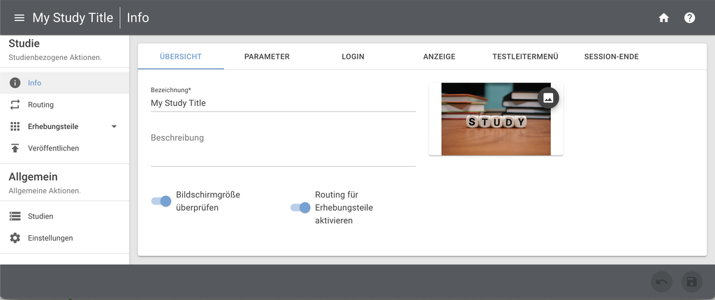

Detaillierte Informationen zu der Grundkonfiguration einer Studie finden sich hier in der eingebetteten Hilfe:

**Embedded Help**

[interactive chart not shown]

### Zugang zu Studien (Login)

Die *IRTlib Software* unterstützt verschiedene Wege, wie sich Personen (Testteilnehmer, Befragte, …) für ein Assessment Authentifizieren können. Die Konfiguratinen umfassen zwei Aspekte:

- *Login-Modus*: Wird ein Zugang benötigt (Login, Login+Passwort, Passphrases/Token) oder nicht? Und wenn Zugangsdaten benötigt werden, was sind *gültige Werge*?
- *Loginquelle*: Wie wird die Login-Information abgefragt (direkte Eingabe auf der Plattform, CBA ItemBuilder Item, ….) oder übergeben (Login-Parameter oder Aufruf-Parameter)?

Detaillierte Informationen zu der Konfiguration der Anmeldung einer *Studie* finden sich hier in der eingebetteten Hilfe:

**Embedded Help**

[interactive chart not shown]

### Konfiguration zur Anzeige

*Studien* können festlegen, wie der *CBA ItemBuilder*-Inhalt dargestellt werden soll. Die Einstellungen im Aschnitt *Anzeige* können sich auf die Skalierung und die Ausrichtung der Inhalte sowie auf das Verhalten der *IRTlib-Player*-Anwendung beziehen.

Detaillierte Informationen zu der Konfiguration der *Anzeige* einer *Studie* finden sich hier in der eingebetteten Hilfe:

**Embedded Help**

[interactive chart not shown]

### Konfiguration des Testleitermenüs

Wenn die Durchführung von Assessments begleitet durch Testleiter oder Interviewer erfolgt, können Funktionen passwortgeschützt für Testleiter definiert werden.

**Warning**

Auch wenn Sie die Funktionalität eines Testadministratormenüs für die Durchführung Ihrer Datenerfassung nicht benötigen, sollten Sie dennoch ein Testadministratormenü definieren, wenn Sie planen, mit dem *IRTlib Player* Daten offline zu erfassen. Nur so können Sie sicherstellen, dass Sie die Anwendung im Falle unvorhergesehener Ereignisse ohne den Task-Manager (und ohne möglichen Datenverlust) beenden können.

Detaillierte Informationen zu der Konfiguration des *Testleitermenüs* finden sich hier in der eingebetteten Hilfe:

**Embedded Help**

[interactive chart not shown]

### Konfiguration des Session-Ende

Für die Integration von Assessments in externe Abläufe besteht die Möglichkeit zu konfiguriere, wie nach der Bearbeitung der Assessmentinhalte in einer *Session* vorgegangen werden soll, was also am *Session-Ende* geschehen wird.

**Embedded Help**

[interactive chart not shown]